# GLMM

Jonathan Zhang

4/6/2020

### Setup

```r
library(tidyverse)
library(stats)
library(lme4)
dat <- readRDS("dat2.rds")
```

### Generalized Mixed Model

We use a log linear mixed model to model the number of new cases.

$log(E[Y_{ij}|b_i])=\beta_0+\beta_1 Time_{ij}+\beta_2 Time_{ij}^2+\beta_3 GHSScore_i+\beta_4 AgeGEQ65_i+\beta_5 UrbanPop_i+b_{i0}+b_{i1}Time_{ij}$

We could consider another random effect for $Time_{ij}^2$ as well.

We remove NAs that could arise from missing data on certain countries, or from inconsistent naming.

```r
dat <- dat %>% mutate(day2 = day^2) %>% drop_na(AgeGEQ65) %>% drop_na(UrbanPop)
```

We fit the previous model, with and without the $Time_{ij}^2$ random effect term with glmer

```r
glmm1 <- glmer(new_cases ~ day + day2 + GHS_Score + AgeGEQ65 + UrbanPop + (day | Country.Region), data = dat, family = poisson)
```

```
## Warning in checkConv(attr(opt, "derivs"), opt$par, ctrl = control$checkConv, :
## Model failed to converge with max|grad| = 0.107775 (tol = 0.001, component 1)
```

```
## Warning in checkConv(attr(opt, "derivs"), opt$par, ctrl = control$checkConv, : Model is nearly unidentifiable: very large eigenvalue
##  - Rescale variables?;Model is nearly unidentifiable: large eigenvalue ratio
##  - Rescale variables?
```

```r
glmm2 <- glmer(new_cases ~ day + day2 + GHS_Score + AgeGEQ65 + UrbanPop + (day + day2 | Country.Region), data = dat, family = poisson)
```

```
## Warning in checkConv(attr(opt, "derivs"), opt$par, ctrl = control$checkConv, : Model failed to converge with max|grad| = 0.011346 (tol = 0.001, component 1)

## Warning in checkConv(attr(opt, "derivs"), opt$par, ctrl = control$checkConv, : Model is nearly unidentifiable: very large eigenvalue
##  - Rescale variables?;Model is nearly unidentifiable: large eigenvalue ratio
##  - Rescale variables?
```

There are a couple of warnings here. The first deals with non-convergence, which could be caused by having multiple random and fixed effects. I tried using both bobyqa and Nelder-Mead for the optimzation algorithm in glmer but could not achieve convergence at their threshold. A model with only two random effects (intercept and day) and two fixed effects (intercept and day) does not have this error. The second warning deals with unidentifiability. I have tried rescaling parameters by normalizing them and using the log odds from percentiles but could not get this warning to go away either. Nonetheless, we still get a fit.

```r
summary(glmm1)
```

```
## Generalized linear mixed model fit by maximum likelihood (Laplace
##   Approximation) [glmerMod]
##  Family: poisson  ( log )
## Formula: new_cases ~ day + day2 + GHS_Score + AgeGEQ65 + UrbanPop + (day |
##     Country.Region)
##    Data: dat
##
##      AIC      BIC   logLik deviance df.resid
## 170085.9 170137.0 -85033.9 170067.9     2155
##
## Scaled residuals:
##     Min      1Q  Median      3Q     Max
##  -50.60   -2.77   -0.40    2.09 1501.90
##
## Random effects:
##  Groups         Name        Variance Std.Dev. Corr
##  Country.Region (Intercept) 1.90720  1.3810
##                 day         0.01059  0.1029   -0.51
## Number of obs: 2164, groups:  Country.Region, 105
##
## Fixed effects:
##               Estimate Std. Error  z value Pr(>|z|)
## (Intercept)  7.409e-01  6.013e-01    1.232  0.21787
## day          1.897e-01  1.041e-02   18.235  < 2e-16 ***
## day2        -4.903e-03  1.746e-05 -280.756  < 2e-16 ***
## GHS_Score    3.340e-02  1.259e-02    2.653  0.00797 **
## AgeGEQ65     1.467e-02  2.251e-02    0.652  0.51455
## UrbanPop    -1.659e-03  6.606e-03   -0.251  0.80170
## ---
## Signif. codes:  0 '***' 0.001 '**' 0.01 '*' 0.05 '.' 0.1 ' ' 1
##
## Correlation of Fixed Effects:
##           (Intr) day    day2   GHS_Sc AGEQ65
## day       -0.098
## day2       0.003 -0.040
## GHS_Score -0.658  0.002  0.001
## AgeGEQ65   0.184 -0.004  0.000 -0.515
## UrbanPop  -0.482 -0.022  0.000 -0.198 -0.115
## convergence code: 0
## Model failed to converge with max|grad| = 0.107775 (tol = 0.001, component 1)
## Model is nearly unidentifiable: very large eigenvalue
##  - Rescale variables?
## Model is nearly unidentifiable: large eigenvalue ratio
##  - Rescale variables?
```

```r
summary(glmm2)
```

```
## Generalized linear mixed model fit by maximum likelihood (Laplace
##   Approximation) [glmerMod]
##  Family: poisson  ( log )
## Formula: new_cases ~ day + day2 + GHS_Score + AgeGEQ65 + UrbanPop + (day +
##     day2 | Country.Region)
##    Data: dat
##
##      AIC      BIC   logLik deviance df.resid
## 156509.3 156577.4 -78242.6 156485.3     2152
##
## Scaled residuals:
##    Min     1Q Median     3Q    Max
## -49.52  -2.33  -0.28   2.00 534.49
##
## Random effects:
##  Groups         Name        Variance  Std.Dev. Corr
##  Country.Region (Intercept) 1.379e+00 1.174511
##                 day         3.856e-02 0.196363 -0.49
##                 day2        8.307e-05 0.009114  0.27 -0.85
## Number of obs: 2164, groups:  Country.Region, 105
##
## Fixed effects:
##               Estimate Std. Error z value Pr(>|z|)
## (Intercept)  1.3395148  0.4684285   2.860  0.00424 **
## day          0.1494836  0.0199796   7.482 7.33e-14 ***
## day2        -0.0024419  0.0009684  -2.521  0.01169 *
## GHS_Score    0.0167286  0.0105147   1.591  0.11162
## AgeGEQ65     0.0235689  0.0184879   1.275  0.20237
## UrbanPop     0.0023651  0.0053165   0.445  0.65642
## ---
## Signif. codes:  0 '***' 0.001 '**' 0.01 '*' 0.05 '.' 0.1 ' ' 1
##
## Correlation of Fixed Effects:
##           (Intr) day    day2   GHS_Sc AGEQ65
## day       -0.121
## day2       0.087 -0.842
## GHS_Score -0.658  0.004 -0.007
## AgeGEQ65   0.196  0.001 -0.003 -0.509
## UrbanPop  -0.402 -0.007 -0.015 -0.276 -0.117
## convergence code: 0
## Model failed to converge with max|grad| = 0.011346 (tol = 0.001, component 1)
## Model is nearly unidentifiable: very large eigenvalue
##  - Rescale variables?
## Model is nearly unidentifiable: large eigenvalue ratio
##  - Rescale variables?
```

For Model 2, it seems that for fixed effects, all but GHS_Score, AgeGEQ65 and UrbanPop were significant.

We now compare the model to the observed counts for several different countries and view their predictions.

### US Model 1

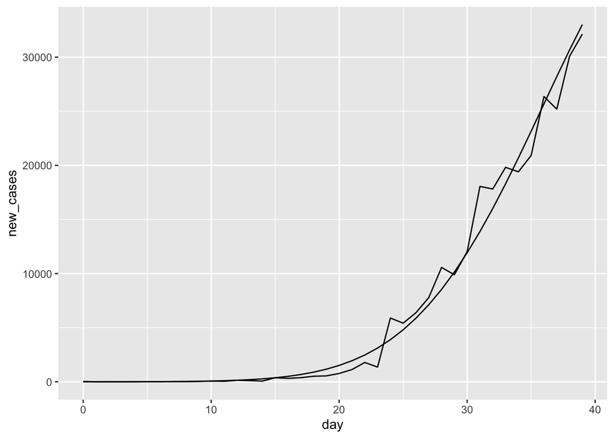

```r
country = 103
country_name = 'US'
rand_ef = ranef(glmm1)$Country.Region[country,]
fix_ef = fixef(glmm1)
coef = c(fix_ef[[1]]+rand_ef[[1]],fix_ef[[2]]+rand_ef[[2]],fix_ef[[3]],fix_ef[[4]],fix_ef[[5]],fix_ef[[6]])
dat2 <- dat %>%
  filter(Country.Region==country_name) %>%
  mutate(model=exp(coef[1]+coef[2]*day+coef[3]*day^2+coef[[4]]*GHS_Score+fix_ef[[5]]*AgeGEQ65+fix_ef[[6]]*UrbanPop))
ggplot(data=dat2)+geom_line(aes(x=day,y=new_cases))+geom_line(aes(x=day,y=model))
```

and the prediction

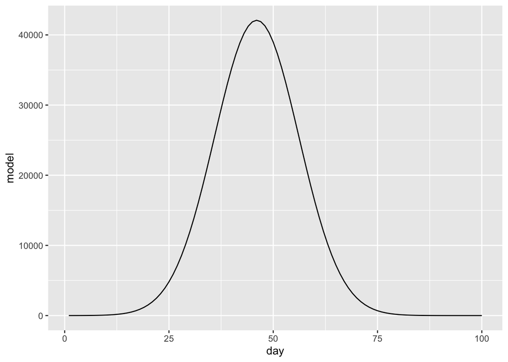

```r
t<-tibble(day=1:100)%>%mutate(day2=(1:100)^2,GHS_Score=dat2$GHS_Score[1],AgeGEQ65=dat2$AgeGEQ65[1],UrbanPop=dat2$UrbanPop[1])%>%
  mutate(model=exp(coef[1]+coef[2]*day+coef[3]*day^2+coef[[4]]*GHS_Score+fix_ef[[5]]*AgeGEQ65+fix_ef[[6]]*UrbanPop))
ggplot(data=t)+geom_line(aes(x=day,y=model))
```

### US Model 2

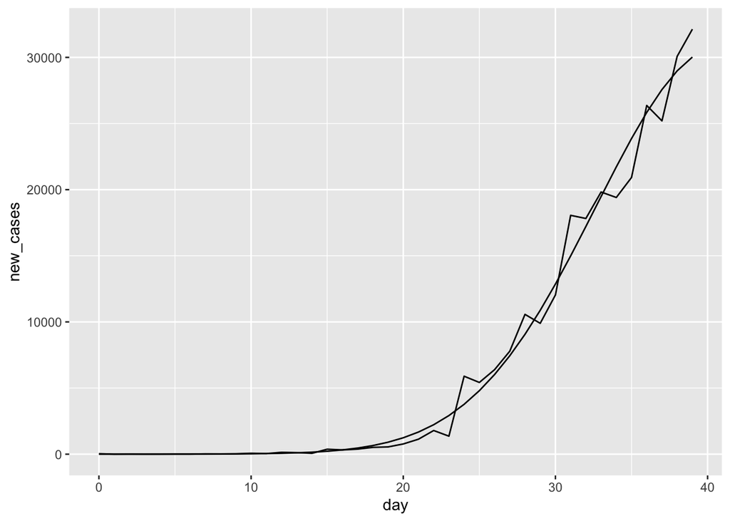

```r
country = 103
country_name = 'US'
rand_ef = ranef(glmm2)$Country.Region[country,]
fix_ef = fixef(glmm2)
coef = c(fix_ef[[1]]+rand_ef[[1]],fix_ef[[2]]+rand_ef[[2]],fix_ef[[3]]+rand_ef[[3]],fix_ef[[4]],fix_ef[[5]],fix_ef[[6]])
dat2 <- dat %>%
  filter(Country.Region==country_name) %>%
  mutate(model=exp(coef[1]+coef[2]*day+coef[3]*day^2+coef[[4]]*GHS_Score+fix_ef[[5]]*AgeGEQ65+fix_ef[[6]]*UrbanPop))
ggplot(data=dat2)+geom_line(aes(x=day,y=new_cases))+geom_line(aes(x=day,y=model))
```

and the prediction

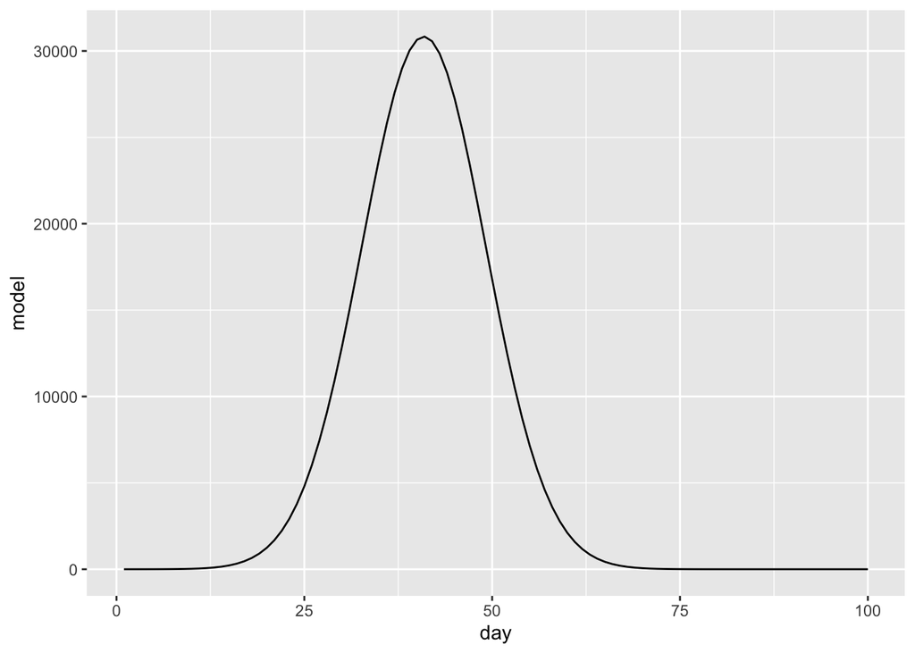

```r
t<-tibble(day=1:100)%>%mutate(day2=(1:100)^2,GHS_Score=dat2$GHS_Score[1],AgeGEQ65=dat2$AgeGEQ65[1],UrbanPop=dat2$UrbanPop[1])%>%
  mutate(model=exp(coef[1]+coef[2]*day+coef[3]*day^2+coef[[4]]*GHS_Score+fix_ef[[5]]*AgeGEQ65+fix_ef[[6]]*UrbanPop))
ggplot(data=t)+geom_line(aes(x=day,y=model))
```

### China Model 1

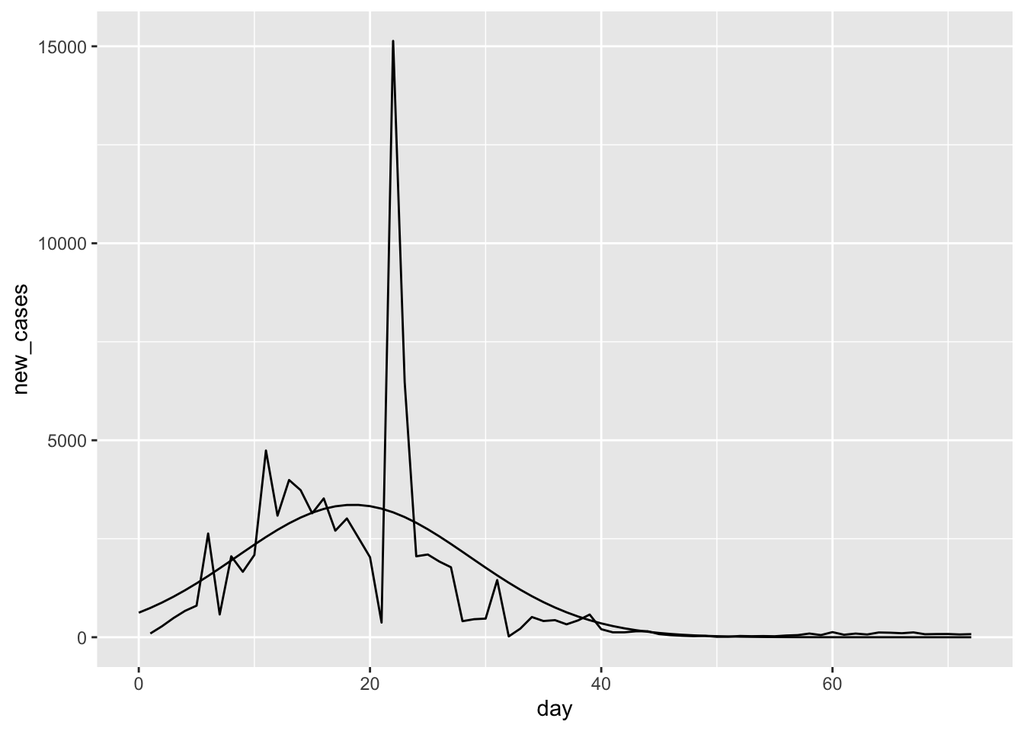

```r
country = 23
country_name = 'China'
rand_ef = ranef(glmm1)$Country.Region[country,]
fix_ef = fixef(glmm1)
coef = c(fix_ef[[1]]+rand_ef[[1]],fix_ef[[2]]+rand_ef[[2]],fix_ef[[3]],fix_ef[[4]],fix_ef[[5]],fix_ef[[6]])
dat2 <- dat %>%
  filter(Country.Region==country_name) %>%
  mutate(model=exp(coef[1]+coef[2]*day+coef[3]*day^2+coef[[4]]*GHS_Score+fix_ef[[5]]*AgeGEQ65+fix_ef[[6]]*UrbanPop))
ggplot(data=dat2)+geom_line(aes(x=day,y=new_cases))+geom_line(aes(x=day,y=model))
```

and the prediction

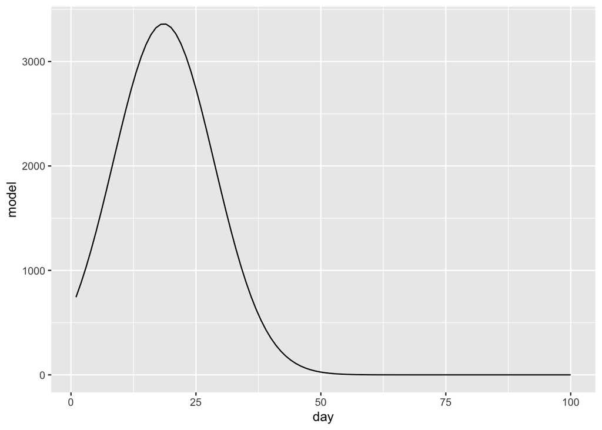

```r
t<-tibble(day=1:100)%>%mutate(day2=(1:100)^2,GHS_Score=dat2$GHS_Score[1],AgeGEQ65=dat2$AgeGEQ65[1],UrbanPop=dat2$UrbanPop[1])%>%
  mutate(model=exp(coef[1]+coef[2]*day+coef[3]*day^2+coef[[4]]*GHS_Score+fix_ef[[5]]*AgeGEQ65+fix_ef[[6]]*UrbanPop))
ggplot(data=t)+geom_line(aes(x=day,y=model))
```

### China Model 2

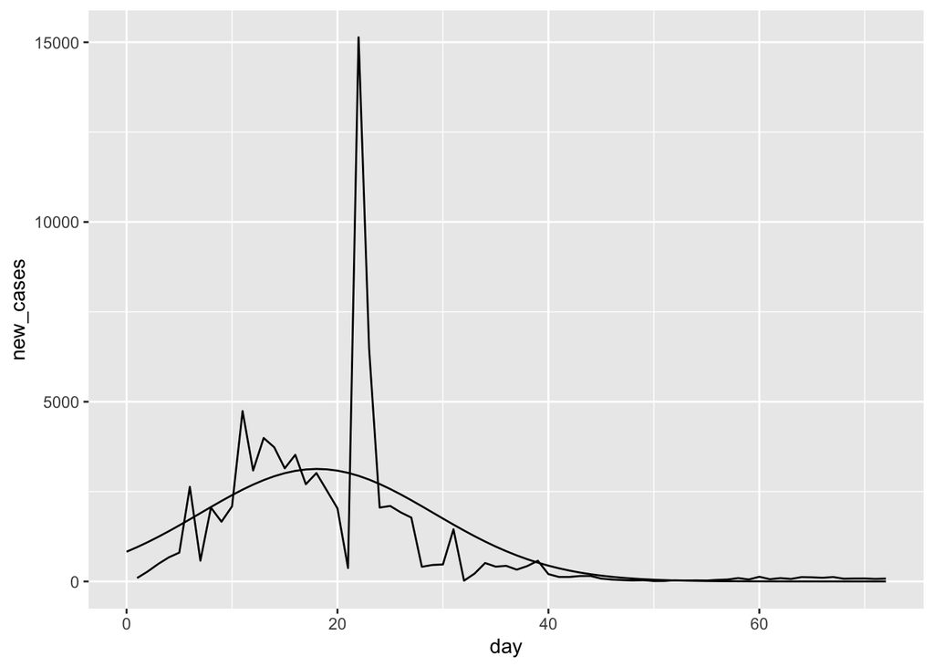

```r
country = 23
country_name = 'China'
rand_ef = ranef(glmm2)$Country.Region[country,]
fix_ef = fixef(glmm2)
coef = c(fix_ef[[1]]+rand_ef[[1]],fix_ef[[2]]+rand_ef[[2]],fix_ef[[3]]+rand_ef[[3]],fix_ef[[4]],fix_ef[[5]],fix_ef[[6]])
dat2 <- dat %>%
  filter(Country.Region==country_name) %>%
  mutate(model=exp(coef[1]+coef[2]*day+coef[3]*day^2+coef[[4]]*GHS_Score+fix_ef[[5]]*AgeGEQ65+fix_ef[[6]]*UrbanPop))
ggplot(data=dat2)+geom_line(aes(x=day,y=new_cases))+geom_line(aes(x=day,y=model))
```

and the prediction

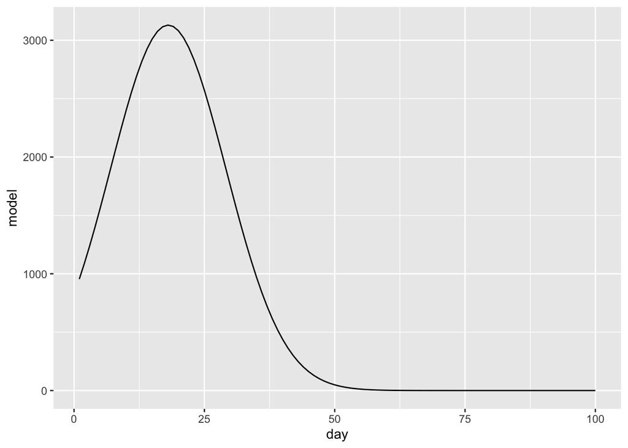

```r
t<-tibble(day=1:100)%>%mutate(day2=(1:100)^2,GHS_Score=dat2$GHS_Score[1],AgeGEQ65=dat2$AgeGEQ65[1],UrbanPop=dat2$UrbanPop[1])%>%
  mutate(model=exp(coef[1]+coef[2]*day+coef[3]*day^2+coef[[4]]*GHS_Score+fix_ef[[5]]*AgeGEQ65+fix_ef[[6]]*UrbanPop))
ggplot(data=t)+geom_line(aes(x=day,y=model))
```

### South Korea Model 1

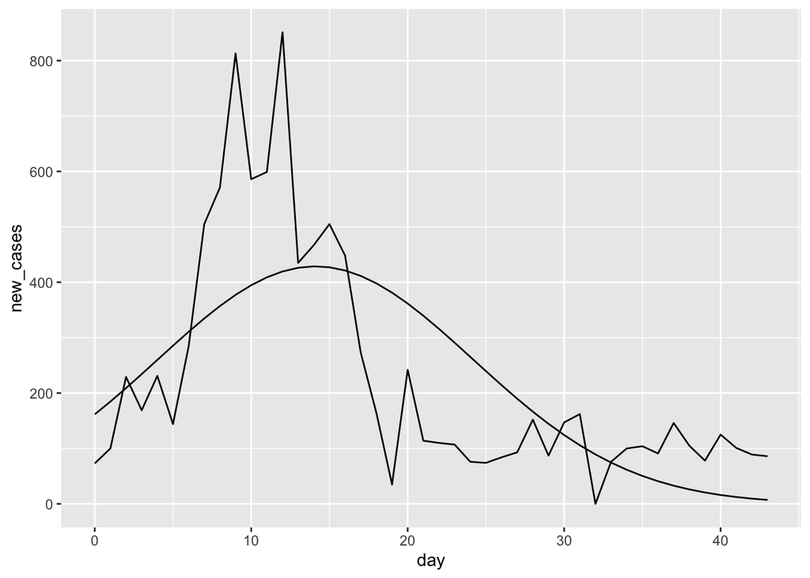

```r
country = 54
country_name = 'Korea, South'
rand_ef = ranef(glmm1)$Country.Region[country,]
fix_ef = fixef(glmm1)
coef = c(fix_ef[[1]]+rand_ef[[1]],fix_ef[[2]]+rand_ef[[2]],fix_ef[[3]],fix_ef[[4]],fix_ef[[5]],fix_ef[[6]])
dat2 <- dat %>%
  filter(Country.Region==country_name) %>%
  mutate(model=exp(coef[1]+coef[2]*day+coef[3]*day^2+coef[[4]]*GHS_Score+fix_ef[[5]]*AgeGEQ65+fix_ef[[6]]*UrbanPop))
ggplot(data=dat2)+geom_line(aes(x=day,y=new_cases))+geom_line(aes(x=day,y=model))
```

and the prediction

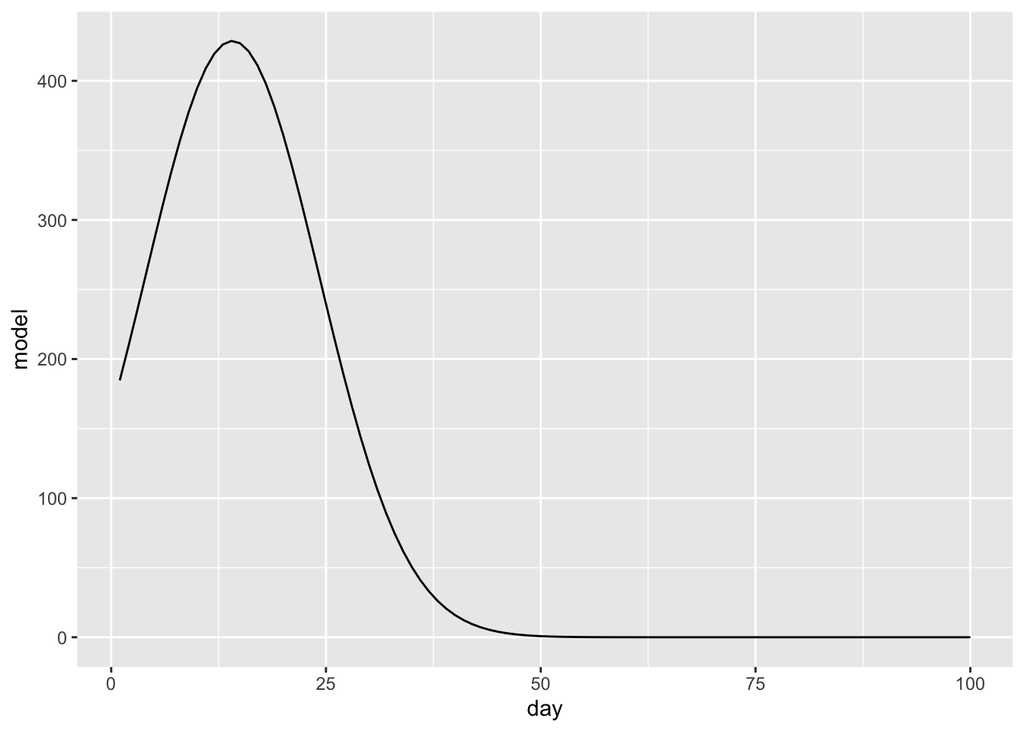

```r
t<-tibble(day=1:100)%>%mutate(day2=(1:100)^2,GHS_Score=dat2$GHS_Score[1],AgeGEQ65=dat2$AgeGEQ65[1],UrbanPop=dat2$UrbanPop[1])%>%
  mutate(model=exp(coef[1]+coef[2]*day+coef[3]*day^2+coef[[4]]*GHS_Score+fix_ef[[5]]*AgeGEQ65+fix_ef[[6]]*UrbanPop))
ggplot(data=t)+geom_line(aes(x=day,y=model))
```

### South Korea Model 2

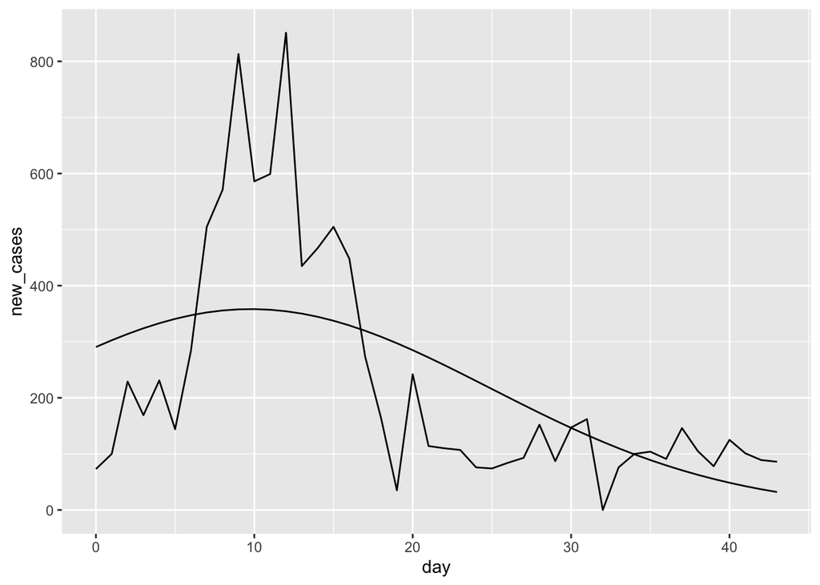

```r
country = 54
country_name = 'Korea, South'
rand_ef = ranef(glmm2)$Country.Region[country,]
fix_ef = fixef(glmm2)
coef = c(fix_ef[[1]]+rand_ef[[1]],fix_ef[[2]]+rand_ef[[2]],fix_ef[[3]]+rand_ef[[3]],fix_ef[[4]],fix_ef[[5]],fix_ef[[6]])
dat2 <- dat %>%
  filter(Country.Region==country_name) %>%
  mutate(model=exp(coef[1]+coef[2]*day+coef[3]*day^2+coef[[4]]*GHS_Score+fix_ef[[5]]*AgeGEQ65+fix_ef[[6]]*UrbanPop))
ggplot(data=dat2)+geom_line(aes(x=day,y=new_cases))+geom_line(aes(x=day,y=model))
```

and the prediction

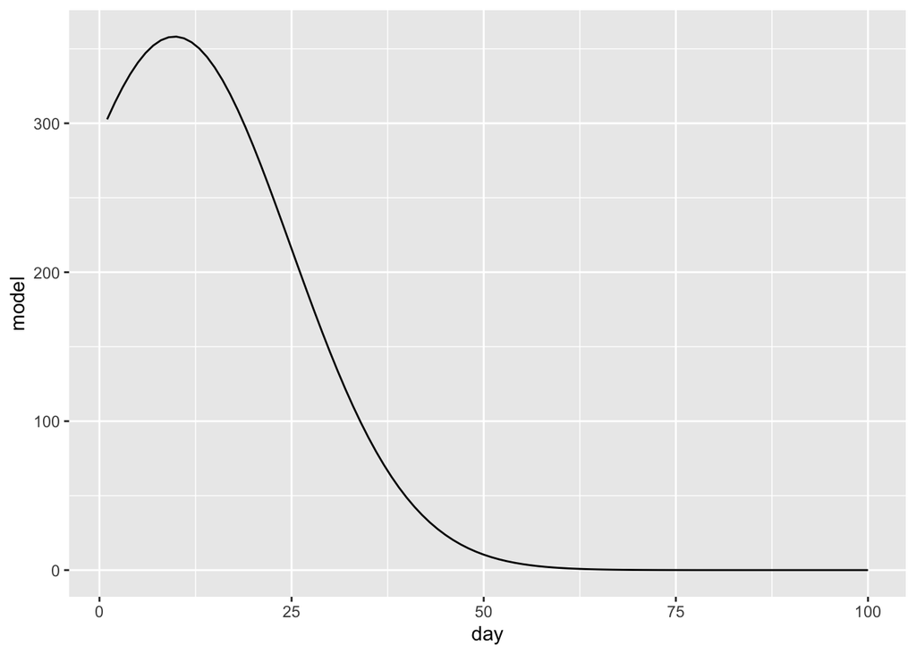

```r
t<-tibble(day=1:100)%>%mutate(day2=(1:100)^2,GHS_Score=dat2$GHS_Score[1],AgeGEQ65=dat2$AgeGEQ65[1],UrbanPop=dat2$UrbanPop[1])%>%
  mutate(model=exp(coef[1]+coef[2]*day+coef[3]*day^2+coef[[4]]*GHS_Score+fix_ef[[5]]*AgeGEQ65+fix_ef[[6]]*UrbanPop))
ggplot(data=t)+geom_line(aes(x=day,y=model))
```